# R Basics

R is a programming language used for statistical computing and graphical presentation.

Its most common use is to analyze and visualize data.

Why Use R? It is a great resource for data analysis, data visualization, data science and machine learning It provides many statistical techniques (such as statistical tests, classification, clustering and data reduction) It is easy to draw graphs in R, like pie charts, histograms, box plot, scatter plot, etc++ It works on different platforms (Windows, Mac, Linux) It is open-source and free It has a large community support It has many packages (libraries of functions) that can be used to solve different problems

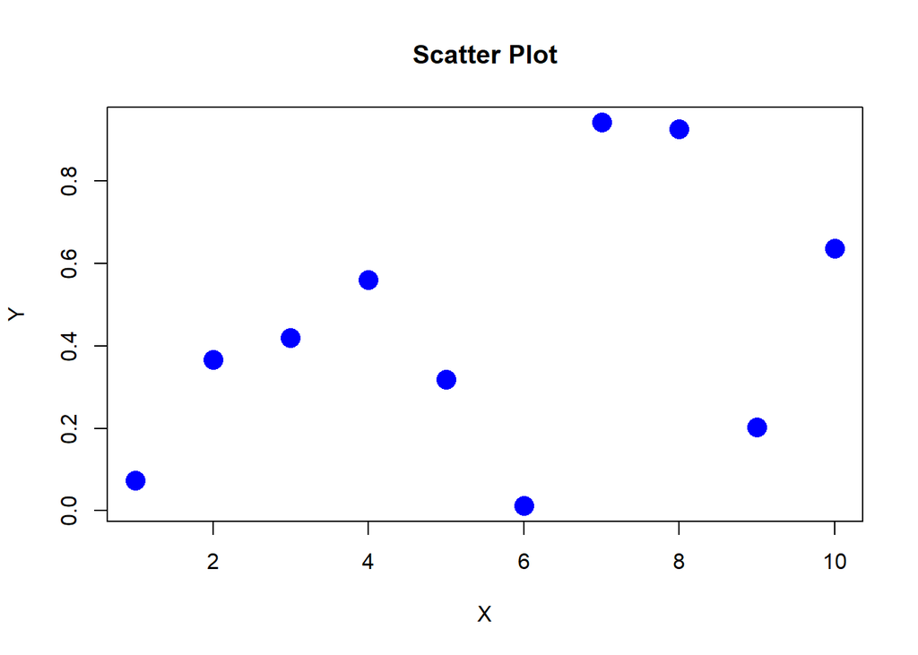

```r
# Generate random data
x <- 1:10
y <- runif(10)

# Create scatter plot with colors and formatting
plot(x, y, type = "p", pch = 16, col = "blue", cex = 2,
     xlab = "X", ylab = "Y", main = "Scatter Plot")
```

# Comments

Comments can be used to explain R code, and to make it more readable. It can also be used to prevent execution when testing alternative code.

Comments starts with a #. When executing code, R will ignore anything that starts with #.

In RStudio a code cell needs to be created and then ran.

This example uses a comment before a line of code:

```r
# This is a comment
"Hello Universe!"
```

```
## [1] "Hello Universe!"
```

This example uses a comment at the end of a line of code:

```r
"Hello Universe!" # This is a comment
```

```
## [1] "Hello Universe!"
```

Comments does not have to be text to explain the code, it can also be used to prevent R from executing the code:

```r
# "Good morning!"
"Good night!"
```

```
## [1] "Good night!"
```

# Multiline Comments

Unlike other programming languages, such as Java, there are no syntax in R for multiline comments. However, we can just insert a # for each line to create multiline comments:

```r
# This is a comment
# written in
# more than just one line
"Hello World!"
```

```
## [1] "Hello World!"
```

# Creating Variables in R

Variables are containers for storing data values.

R does not have a command for declaring a variable. A variable is created the moment you first assign a value to it. To assign a value to a variable, use the <- sign. To output (or print) the variable value, type the variable name:

```r
name <- "John Carpenter"
age <- 75
profession <- "Director"

name   # output "John Carpenter"
```

```
## [1] "John Carpenter"
```

```r
age    # output 75
```

```
## [1] 75
```

```r
profession   # output "Director"
```

```
## [1] "Director"
```

# Concatenate Elements

You can concatenate, or join, two or more elements, by using paste().

To combine both text and a variable, R uses comma (,):

```r
text <- "awesome"

paste("John Carpenter's", text)
```

```
## [1] "John Carpenter's awesome"
```

You can also use , to add a variable to another variable:

```r
text1 <- "John Carpenter's"
text2 <- "awesome"

paste(text1, text2)
```

```
## [1] "John Carpenter's awesome"
```

For numbers, the + character works as a mathematical operator, If you try to combine a string (text) and a number, R will give you an error:

```r
num1 <- 5
num2 <- 10

num1 + num2
```

```
## [1] 15
```

# Multiple Variables

R allows you to assign the same value to multiple variables in one line:

```r
# Assign the same value to multiple variables in one line
var1 <- var2 <- var3 <- "Halloween"

# Print variable values
var1
```

```
## [1] "Halloween"
```

```r
var2
```

```
## [1] "Halloween"
```

```r
var3
```

```
## [1] "Halloween"
```

In R, variables do not need to be declared with any particular type, and can even change type after they have been set.

# Basic Data Types

Basic data types in R can be divided into the following types:

numeric - (10.5, 55, 787) integer - (1L, 55L, 100L, where the letter “L” declares this as an integer) complex - (9 + 3i, where “i” is the imaginary part) character (a.k.a. string) - (“k”, “R is exciting”, “FALSE”, “11.5”) logical (a.k.a. boolean) - (TRUE or FALSE) Use the class() function to check the data type of a variable:

```r
# numeric
num <- 10.5
class(num)
```

```
## [1] "numeric"
```

```r
# integer
int <- 1000L
class(int)
```

```
## [1] "integer"
```

```r
# complex
comp <- 9i + 3
class(comp)
```

```
## [1] "complex"
```

```r
# character/string
chr <- "R is exciting"
class(chr)
```

```
## [1] "character"
```

```r
# logical/boolean
bool <- TRUE
class(bool)
```

```
## [1] "logical"
```

# Type Conversion

You can convert from one type to another with the following functions:

as.numeric() as.integer() as.complex()

```r
x <- 1L # integer
y <- 2 # numeric

# convert from integer to numeric:
a <- as.numeric(x)

# convert from numeric to integer:
b <- as.integer(y)

# print values of x and y
x
```

```
## [1] 1
```

```r
y
```

```
## [1] 2
```

```r
# print the class name of a and b
class(a)
```

```
## [1] "numeric"
```

```r
class(b)
```

```
## [1] "integer"
```

# Simple Math

In R, you can use operators to perform common mathematical operations on numbers.

The + operator is used to add together two values:

```r
# Addition
5 + 5
```

```
## [1] 10
```

```r
# Subtraction
5 - 3
```

```
## [1] 2
```

```r
# Division
2 / 4
```

```
## [1] 0.5
```

```r
# Multiplication
3 * 3
```

```
## [1] 9
```

# Built-in Math Functions

R also has many built-in math functions that allows you to perform mathematical tasks on numbers.

For example, the min() and max() functions can be used to find the lowest or highest number in a set:

```r
max(5, 10, 15)
```

```
## [1] 15
```

```r
min(5, 10, 15)
```

```
## [1] 5
```

# sqrt()

The sqrt() function returns the square root of a number:

```r
sqrt(16)
```

```
## [1] 4
```

# abs()

The abs() function returns the absolute (positive) value of a number:

```r
abs(-4.7)
```

```
## [1] 4.7
```

# ceiling() and floor()

The ceiling() function rounds a number upwards to its nearest integer, and the floor() function rounds a number downwards to its nearest integer, and returns the result:

```r
ceiling(1.4)
```

```
## [1] 2
```

```r
floor(1.4)
```

```
## [1] 1
```

#String Literals

Strings are used for storing text.

A string is surrounded by either single quotation marks, or double quotation marks:

“hello” is the same as ‘hello’:

```r
"Freddy"
```

```
## [1] "Freddy"
```

```r
'Krueger'
```

```
## [1] "Krueger"
```

# Assign a String to a Variable

Assigning a string to a variable is done with the variable followed by the <- operator and the string:

```r
str <- "Hello"
str # print the value of str
```

```
## [1] "Hello"
```

# Multiline Strings

You can assign a multiline string to a variable like this:

```r
str <- "Lorem ipsum dolor sit amet,
consectetur adipiscing elit,
sed do eiusmod tempor incididunt
ut labore et dolore magna aliqua."

str # print the value of str
```

```
## [1] "Lorem ipsum dolor sit amet,\nconsectetur adipiscing elit,\nsed do eiusmod tempor incididunt\nut labore et dolore magna aliqua."
```

If you want the line breaks to be inserted at the same position as in the code, use the cat() function:

```r
str <- "Lorem ipsum dolor sit amet,
consectetur adipiscing elit,
sed do eiusmod tempor incididunt
ut labore et dolore magna aliqua."

cat(str)
```

```
## Lorem ipsum dolor sit amet,
## consectetur adipiscing elit,
## sed do eiusmod tempor incididunt
## ut labore et dolore magna aliqua.
```

# String Length

There are many usesful string functions in R.

For example, to find the number of characters in a string, use nchar():

```r
str <- "Hello Universe!"

nchar(str)
```

```
## [1] 15
```

# Check a String

Use the grepl() function to check if a character or a sequence of characters are present in a string:

```r
str <- "Hello Universe!"

grepl("H", str)
```

```
## [1] TRUE
```

```r
grepl("Hello", str)
```

```
## [1] TRUE
```

```r
grepl("X", str)
```

```
## [1] FALSE
```

# Combine Two Strings

Use the paste() function to merge/concatenate two strings:

```r
str1 <- "Hello"
str2 <- "Universe"

paste(str1, str2)
```

```
## [1] "Hello Universe"
```

# Escape Characters

To insert characters that are illegal in a string, you must use an escape character.

An escape character is a backslash followed by the character you want to insert.

An example of an illegal character is a double quote inside a string that is surrounded by double quotes:

```r
# str <- "We are the so-called "Vikings", from the north."
# Error: unexpected symbol in "str <- "We are the so-called "Vikings"
```

```r
str <- "We are the so-called \"Vikings\", from the north."

str
```

```
## [1] "We are the so-called \"Vikings\", from the north."
```

```r
cat(str)
```

```
## We are the so-called "Vikings", from the north.
```

# Booleans (Logical Values)

In programming, you often need to know if an expression is true or false.

You can evaluate any expression in R, and get one of two answers, TRUE or FALSE.

When you compare two values, the expression is evaluated and R returns the logical answer:

```r
10 > 2   # TRUE because 10 is greater than 2
```

```
## [1] TRUE
```

```r
10 == 3   # FALSE because 10 is not equal to 3
```

```
## [1] FALSE
```

```r
10 < 4    # FALSE because 10 is greater than 4
```

```
## [1] FALSE
```

You can also compare two variables:

```r
a <- 10
b <- 3

a > b
```

```
## [1] TRUE
```

You can also run a condition in an if statement, which you will learn much more about in the if..else chapter.

```r
a <- 2342
b <- 95345

if (b > a) {
  print ("b is greater than a")
} else {
  print("b is not greater than a")
}
```

```
## [1] "b is greater than a"
```

# Operators

R divides the operators in the following groups:

Arithmetic operators Assignment operators Comparison operators Logical operators Miscellaneous operators R Arithmetic Operators Arithmetic operators are used with numeric values to perform common mathematical operations:

Operator Name Example + Addition x + y  
- Subtraction x - y * Multiplication x * y / Division x / y  
^ Exponent x ^ y  
%% Modulus (Remainder from division) x %% y  
%/% Integer Division x%/%y

# R Assignment Operators

Assignment operators are used to assign values to variables:

```r
my_var <- 3

my_var <<- 3

3 -> my_var

3 ->> my_var

my_var # print my_var
```

```
## [1] 3
```

# R Comparison Operators

Comparison operators are used to compare two values:

Operator Name Example == Equal x == y  
!= Not equal x != y  
> Greater than x > y  
< Less than x < y  
>= Greater than or equal to x >= y  
<= Less than or equal to x <= y

# R Logical Operators

Logical operators are used to combine conditional statements:

Operator Description & Element-wise Logical AND operator. It returns TRUE if both elements are TRUE && Logical AND operator - Returns TRUE if both statements are TRUE | Elementwise- Logical OR operator. It returns TRUE if one of the statement is TRUE || Logical OR operator. It returns TRUE if one of the statement is TRUE. ! Logical NOT - returns FALSE if statement is TRUE

# R Miscellaneous Operators

Miscellaneous operators are used to manipulate data:

**Operator Description Example**

[output not shown]

%in% Find out if an element belongs to a vector x %in% y %*% Matrix Multiplication x <- Matrix1 %*% Matrix2

# Conditions and If Statements

R supports the usual logical conditions from mathematics:

Operator Name Example == Equal x == y  
!= Not equal x != y  
> Greater than x > y  
< Less than x < y  
>= Greater than or equal to x >= y  
<= Less than or equal to x <= y

These conditions can be used in several ways, most commonly in “if statements” and loops

# The if Statement

An “if statement” is written with the if keyword, and it is used to specify a block of code to be executed if a condition is TRUE:

```r
a <- 33
b <- 20009000000000000

if (b > a) {
  print("b is greater than a")
}
```

```
## [1] "b is greater than a"
```

# Else If

The else if keyword is R’s way of saying “if the previous conditions were not true, then try this condition”:

```r
a <- 333333333
b <- 333333333

if (b > a) {
  print("b is greater than a")
} else if (a == b) {
  print ("a and b are equal")
}
```

```
## [1] "a and b are equal"
```

In this example a is equal to b, so the first condition is not true, but the else if condition is true, so we print to screen that “a and b are equal”.

You can use as many else if statements as you want.

# If Else

The else keyword catches anything which isn’t caught by the preceding conditions:

```r
a <- 200000000000000000000000000
b <- 3300324123546

if (b > a) {
  print("b is greater than a")
} else if (a == b) {
  print("a and b are equal")
} else {
  print("a is greater than b")
}
```

```
## [1] "a is greater than b"
```

In this example, a is greater than b, so the first condition is not true, also the else if condition is not true, so we go to the else condition and print to screen that “a is greater than b”.

You can also use else without else if:

```r
a <- 200576956795679579
b <- 3346784768

if (b > a) {
  print("b is greater than a")
} else {
  print("b is not greater than a")
}
```

```
## [1] "b is not greater than a"
```

# Nested If Statements

You can also have if statements inside if statements, this is called nested if statements.

```r
x <- 360

if (x > 10) {
  print("Above ten")
  if (x > 2000) {
    print("and also above 20!")
  } else {
    print("but not above 20.")
  }
} else {
  print("below 10.")
}
```

```
## [1] "Above ten"
## [1] "but not above 20."
```

# AND

The & symbol (and) is a logical operator, and is used to combine conditional statements:

```r
# Test if a is greater than b, AND if c is greater than a
a <- 2023
b <- 333
c <- 5000

if (a > b & c > a) {
  print("Both conditions are true")
}
```

```
## [1] "Both conditions are true"
```

# OR

The | symbol (or) is a logical operator, and is used to combine conditional statements:

```r
# Test if a is greater than b, or if c is greater than a

a <- 2002453352
b <- 335235
c <- 50052235235235

if (a > b | a > c) {
  print("At least one of the conditions is true")
}
```

```
## [1] "At least one of the conditions is true"
```

# Loops

Loops can execute a block of code as long as a specified condition is reached.

Loops are handy because they save time, reduce errors, and they make code more readable.

R has two loop commands:

while loops for loops

# R While Loops

With the while loop we can execute a set of statements as long as a condition is TRUE:

```r
#Print i as long as i is less than 6:

i <- 1
while (i < 6) {
  print(i)
  i <- i + 1
}
```

```
## [1] 1
## [1] 2
## [1] 3
## [1] 4
## [1] 5
```

In the example above, the loop will continue to produce numbers ranging from 1 to 5. The loop will stop at 6 because 6 < 6 is FALSE.

The while loop requires relevant variables to be ready, in this example we need to define an indexing variable, i, which we set to 1.

Note: remember to increment i, or else the loop will continue forever.

# Break

With the break statement, we can stop the loop even if the while condition is TRUE:

```r
# Exit the loop if i is equal to 4

i <- 1
while (i < 6) {
  print(i)
  i <- i + 1
  if (i == 4) {
    break
  }
}
```

```
## [1] 1
## [1] 2
## [1] 3
```

The loop will stop at 3 because we have chosen to finish the loop by using the break statement when i is equal to 4 (i == 4).

# Next

With the next statement, we can skip an iteration without terminating the loop:

```r
# Skip the value of 3

i <- 0
while (i < 6) {
  i <- i + 1
  if (i == 3) {
    next
  }
  print(i)
}
```

```
## [1] 1
## [1] 2
## [1] 4
## [1] 5
## [1] 6
```

When the loop passes the value 3, it will skip it and continue to loop.

# If .. Else Combined with a While Loop

To demonstrate a practical example, let us say we play a game of Yahtzee!

```r
# Print "Money!" If the dice number is 6

dice <- 1
while (dice <= 6) {
  if (dice < 6) {
    print("No Money")
  } else {
    print("Money!")
  }
  dice <- dice + 1
}
```

```
## [1] "No Money"
## [1] "No Money"
## [1] "No Money"
## [1] "No Money"
## [1] "No Money"
## [1] "Money!"
```

#For Loops

A for loop is used for iterating over a sequence:

```r
for (x in 1:10) {
  print(x)
}
```

```
## [1] 1
## [1] 2
## [1] 3
## [1] 4
## [1] 5
## [1] 6
## [1] 7
## [1] 8
## [1] 9
## [1] 10
```

This is less like the for keyword in other programming languages, and works more like an iterator method as found in other object-orientated programming languages.

With the for loop we can execute a set of statements, once for each item in a vector, array, list, etc..

You will learn about lists and vectors, etc in a later chapter.

```r
# Print every item in a list

movies <- list("The Thing", "Halloween", "Escape From New York")

for (x in movies) {
  print(x)
}
```

```
## [1] "The Thing"
## [1] "Halloween"
## [1] "Escape From New York"
```

```r
# Print the number of dices

dice <- c(1, 2, 3, 4, 5, 6)

for (x in dice) {
  print(x)
}
```

```
## [1] 1
## [1] 2
## [1] 3
## [1] 4
## [1] 5
## [1] 6
```

The for loop does not require an indexing variable to set beforehand, like with while loops.

# Break

With the break statement, we can stop the loop before it has looped through all the items:

```r
# Stop the loop at "The Thing"

movies <- list("The Thing", "Halloween", "Escape From New York")

for (x in movies) {
  if (x == "The Thing") {
    break
  }
  print(x)
}
```

The loop will stop at “The Thing” because we have chosen to finish the loop by using the break statement when x is equal to “The Thing” (x == “The Thing”).

# Next

With the next statement, we can skip an iteration without terminating the loop:

```r
#Skip "Halloween":

movies <- list("The Thing", "Halloween", "Escape From New York")

for (x in movies) {
  if (x == "Halloween") {
    next
  }
  print(x)
}
```

```
## [1] "The Thing"
## [1] "Escape From New York"
```

When the loop passes “Halloween”, it will skip it and continue to loop.

# If .. Else Combined with a For Loop

To demonstrate a practical example, let us say we play a game of Yahtzee!

```r
# Print "Yahtzee!" If the dice number is 6:

dice <- 1:6

for(x in dice) {
  if (x == 6) {
    print(paste("The dice number is", x, "Yahtzee!"))
  } else {
    print(paste("The dice number is", x, "Not Yahtzee"))
  }
}
```

```
## [1] "The dice number is 1 Not Yahtzee"
## [1] "The dice number is 2 Not Yahtzee"
## [1] "The dice number is 3 Not Yahtzee"
## [1] "The dice number is 4 Not Yahtzee"
## [1] "The dice number is 5 Not Yahtzee"
## [1] "The dice number is 6 Yahtzee!"
```

# Nested Loops

It is also possible to place a loop inside another loop. This is called a nested loop:

```r
# Print the adjective of each fruit in a list:

adj <- list("red", "big", "tasty")

fruits <- list("apple", "banana", "cherry")
  for (x in adj) {
    for (y in fruits) {
      print(paste(x, y))
  }
}
```

```
## [1] "red apple"
## [1] "red banana"
## [1] "red cherry"
## [1] "big apple"
## [1] "big banana"
## [1] "big cherry"
## [1] "tasty apple"
## [1] "tasty banana"
## [1] "tasty cherry"
```

# Functions

A function is a block of code which only runs when it is called.

You can pass data, known as parameters, into a function.

A function can return data as a result.

# Creating a Function

To create a function, use the function() keyword:

```r
my_function <- function() { # create a function with the name my_function
  print("Hello Universe!")
}
```

# Call a Function

To call a function, use the function name followed by parenthesis, like my_function():

```r
my_function <- function() {
  print("Hello Universe!")
}

my_function() # call the function named my_function
```

```
## [1] "Hello Universe!"
```

# Arguments

Information can be passed into functions as arguments.

Arguments are specified after the function name, inside the parentheses. You can add as many arguments as you want, just separate them with a comma.

The following example has a function with one argument (fname). When the function is called, we pass along a first name, which is used inside the function to print the full name:

```r
my_function <- function(fname) {
  paste(fname, "Bundy")
}

my_function("AL")
```

```
## [1] "AL Bundy"
```

```r
my_function("Peggy")
```

```
## [1] "Peggy Bundy"
```

```r
my_function("Bud")
```

```
## [1] "Bud Bundy"
```

```r
my_function("Kelly")
```

```
## [1] "Kelly Bundy"
```

# Parameters or Arguments?

The terms “parameter” and “argument” can be used for the same thing: information that are passed into a function.

From a function’s perspective:

A parameter is the variable listed inside the parentheses in the function definition.

An argument is the value that is sent to the function when it is called.

# Number of Arguments

By default, a function must be called with the correct number of arguments. Meaning that if your function expects 2 arguments, you have to call the function with 2 arguments, not more, and not less:

```r
# This function expects 2 arguments, and gets 2 arguments:

my_function <- function(fname, lname) {
  paste(fname, lname)
}

my_function("AL", "Bundy")
```

```
## [1] "AL Bundy"
```

# Default Parameter Value

The following example shows how to use a default parameter value.

If we call the function without an argument, it uses the default value:

```r
my_function <- function(planet = "Mars") {
  paste("I am from", planet)
}

my_function("Jupiter")
```

```
## [1] "I am from Jupiter"
```

```r
my_function("Saturn")
```

```
## [1] "I am from Saturn"
```

```r
my_function() # will get the default value, which is Mars
```

```
## [1] "I am from Mars"
```

```r
my_function("Pluto")
```

```
## [1] "I am from Pluto"
```

# Return Values

To let a function return a result, use the return() function:

```r
my_function <- function(x) {
  return (100 * x)
}

print(my_function(300))
```

```
## [1] 30000
```

```r
print(my_function(500))
```

```
## [1] 50000
```

```r
print(my_function(900))
```

```
## [1] 90000
```

# Nested Functions

There are two ways to create a nested function:

Call a function within another function. Write a function within a function.

```r
# Call a function within another function:

Nested_function <- function(x, y) {
  a <- x + y
  return(a)
}

Nested_function(Nested_function(24,24), Nested_function(35,35))
```

```
## [1] 118
```

Example Explained The function tells x to add y.

The first input Nested_function(24,24) is “x” of the main function.

The second input Nested_function(35,35) is “y” of the main function.

The output is therefore (24+24) + (35+35) = 118.

```r
# Write a function within a function:

Outer_func <- function(x) {
  Inner_func <- function(y) {
    a <- x + y
    return(a)
  }
  return (Inner_func)
}
output <- Outer_func(5) # To call the Outer_func
output(10)
```

```
## [1] 15
```

Example Explained You cannot directly call the function because the Inner_func has been defined (nested) inside the Outer_func.

We need to call Outer_func first in order to call Inner_func as a second step.

# Recursion

R also accepts function recursion, which means a defined function can call itself.

Recursion is a common mathematical and programming concept. It means that a function calls itself. This has the benefit of meaning that you can loop through data to reach a result.

The developer should be very careful with recursion as it can be quite easy to slip into writing a function which never terminates, or one that uses excess amounts of memory or processor power. However, when written correctly, recursion can be a very efficient and mathematically-elegant approach to programming.

In this example, tri_recursion() is a function that we have defined to call itself (“recurse”). We use the k variable as the data, which decrements (-1) every time we recurse. The recursion ends when the condition is not greater than 0 (i.e. when it is 0).

To a new developer it can take some time to work out how exactly this works, best way to find out is by testing and modifying it.

```r
tri_recursion <- function(k) {
  if (k > 0) {
    result <- k + tri_recursion(k - 1)
    print(result)
  } else {
    result = 0
    return(result)
  }
}
tri_recursion(6)
```

```
## [1] 1
## [1] 3
## [1] 6
## [1] 10
## [1] 15
## [1] 21
```

# Global Variables

Variables that are created outside of a function are known as global variables.

Global variables can be used by everyone, both inside of functions and outside.

```r
# Create a variable outside of a function and use it inside the function:

txt <- "rules"
my_function <- function() {
  paste("Hendrix", txt)
}

my_function()
```

```
## [1] "Hendrix rules"
```

If you create a variable with the same name inside a function, this variable will be local, and can only be used inside the function. The global variable with the same name will remain as it was, global and with the original value.

```r
# Create a variable inside of a function with the same name as the global variable:

txt <- "global variable"
my_function <- function() {
  txt = "deadly"
  paste("Freddy is", txt)
}

my_function()
```

```
## [1] "Freddy is deadly"
```

```r
txt # print txt
```

```
## [1] "global variable"
```

If you try to print txt, it will return “global variable” because we are printing txt outside the function.

# The Global Assignment Operator

Normally, when you create a variable inside a function, that variable is local, and can only be used inside that function.

To create a global variable inside a function, you can use the global assignment operator <<-

```r
#If you use the assignment operator <<-, the variable belongs to the global scope:

my_function <- function() {
txt <<- "slimey"
  paste("Slimer is", txt)
}

my_function()
```

```
## [1] "Slimer is slimey"
```

```r
print(txt)
```

```
## [1] "slimey"
```

Also, use the global assignment operator if you want to change a global variable inside a function:

```r
# To change the value of a global variable inside a function, refer to the variable by using the global assignment operator <<-:

txt <- "tubular"
my_function <- function() {
  txt <<- "calming"
  paste("Music can be", txt)
}

my_function()
```

```
## [1] "Music can be calming"
```

```r
paste("Music can be", txt)
```

```
## [1] "Music can be calming"
```